# Data Analysis Report 1

Will Kramlinger

January 13, 2019

## Introduction

Exploratory data analysis (EDA) was conducted on a data set comprising median housing values of various Boston suburbs and potential predictors. Correlations among predictors were examined, with particular attention paid to pairwise correlations with per capita crime rates, of which many were significant. Commonalities amongst predictors were examined for suburbs with low median household values, as well as for suburbs which average a large number of rooms per dwelling.

## Data

The data set analyzed was the **Boston** data set included in the R package **MASS**. The set includes observations for 506 suburbs across 14 variables. For variable definitions, please refer to https://www.rdocumentation.org/packages/MASS/versions/7.3-47/topics/Boston. The following shall presume the reader’s familarity with the variable names and their meanings, as they are used interchangeably. A check for missing data within the set revealed no problems and no cleaning was deemed necessary. A simple 5-number summary for each variable, along with each mean, was calculated as Table 1.

The project was an initial exploration of the data set intended as an exercise in data visualization and basic descriptive statistics. As the scope of this report is limited to EDA, an investigation of possible influential points was not undertaken.

## Analyses

*Correlation among predictors*

Correlation amongst the variables was investigated via scatterplot and correlation matrices. A few of the most highly correlated linear relationships between predictor pairs are shown as Figs. 1a (**nox** vs. **age**, *r* = 0.731) and 1b (**medv** vs **lstat**, *r* = -0.738). While visual inspection of these plots reveals clear trends, which are supported quantitively via the correlation values, the trends do not appear to be strictly linear, but rather curvilinear; this observation holds true for many of the variable pairs. Thus, for future regression analysis, transformation of variables will likely be necessary, with transformations informed via residual analyses. Additionally, if a combination of these variables are used as predictors, a careful approach is advised as to avoid multicollinearity.

*Per capita crime rates*

Of particular interest in this analysis was the per capita crime rate (**crim**) and its association with the other predictors in the data set. While not reflected in the correlation matrix values, the variable demonstrated visible trends for nearly every instance that it was plotted pairwise against the other variables.

Generally, 4 classes of trends were observed:  
1) The full range of crime rate values were found to be mostly included at one particular level of the predictor; at all other levels of the predictor, the crime rates were much more narrowly distributed and nearly equal to the minimum values of all crime rate values in the data set. The subset of predictors for which this trend was observed is discussed further below.  
2) Both the mean response and overall variation in the crime rate values increased as the predictor level either increased (positive correlation; **age** , **lstat**) or decreased (negative correlation; **dist**, **medv**). All of these trends between variable pairs appeared more curvilinear than linear, akin to the previous discussion.  
3) The overall variation in the crime rate values was largest at intermediate values of the predictor, and grew smaller as the predictor levels were moved further away from these intermediate values. In other words, the curves resembled a unimodal distribution. This trend was observed for predictors **nox** and **rm**.  
4) The overall variation in the crime rate values was smallest at intermediate values of the predictor, and grew larger as the predictor levels were moved further away from these intermediate values. In other words, the data resembed a bimodal distribution. This trend was observed for predictor **black**.

The trend of particular note is the first class, which was observed when crime rate (**crim**) was plotted against each of **zn**, **indus**, **chas**, **rad**, **tax**, and **ptratio**. A representative plot of this trend is shown as Fig. 2, where the majority of the variation in crime rate was observed at the specific predictor level **ptratio** = 20.2. Other predictor levels where this pattern was observed included **zn** = 0, **indus** = 18.10, **chas** = 0, **rad** = 24, and **tax** = 666. Furthermore, it was found that of the suburbs in the top 25% (*n* = 127, **crim** > 3.667) in terms of crime rate, 120/127 = 94% of them shared *all* of these specific predictor values. Further analysis revealed that these specific predictor levels, with the exception of **chas** = 0 (see below), are severely over-represented within these high-crime suburbs. Comparison of these predictor levels with the summary in Table 1 reveals that these values are equal to either the 25th (**zn**, **chas**) or 75th (**indus**, **rad**, **tax**, **ptratio**) percentiles for each particular variable in the data set, which suggests a large degree of commonality between these suburbs.

Of practical significance is the observation that this majority of suburbs with high crime rates had no residential lots over 25,000 sq ft (**zn** = 0), full-value property tax rate values which were near the highest observed in the overall data, a relatively high pupil:teacher ratio, and a high index of radial highway accessibility (research into whether a high index indicates high or low accessibility yielded no results). Further investigation of these suburbs is warranted; a spatial analysis may be particularly useful. Additionally, the plausibility of grouping these suburbs into one class should be considered for the sake of variable reduction in future analyses. Please note that **chas** = 0 (i.e., not on the Charles River) is specifically not mentioned for this particular analyses, as it is not considered practically meaningful. For **chas** = 0, the proportion of suburbs in the overall data set (471/506 = 0.931) was found to be not statistically different from the proportion found within the top 25% suburbs in terms of crime rate (120/127 = 0.945) at 99% confidence.

*Median values of owner-occupied homes*

As an initial step into understanding various predictors’ relationships with the median household values (**medv**) of all Boston suburbs, the suburb with the lowest **medv** was identified. Two suburbs were found to have this minimum value of **medv** = 5, namely, suburbs 399 and 406. Each suburb’s predictor levels and corresponding percentiles across the 13 other predictors are tabulated in Table 2.

Inspection of Table 2 reveals that the suburbs under analysis share common predictor levels across the majority of variables, with the exception of the predictor **black**. In terms of percentiles, the two suburbs differ from each other by, at most, 8, with the exception of predictor **black** which differs by 66. Recall the previous discussion about the first class of trends seen for the variable **crim** and the associated predictor levels of **zn**, **indus**, **chas**, **rad**, **tax**, and **ptratio**; these specific levels are also seen for suburbs 399 and 406, suggesting that suburbs with low median household values may be correlated with higher per capita crime rates.

Additionally, the observed values for **nox**, **age**, **rm**, **dis**, and **lstat** are similar for the two suburbs. Specifically, the values of **nox**, **age**, and **lstat** for each suburb reside near the higher end of each variable’s range; the values of **rm** and **dis** reside at the lower ends.  
Practically, this preliminary analysis suggests that suburbs with lower median household values may also be characterized via higher NO concentrations, older homes with relatively few rooms, a higher percentage of lower status population, and close proximities to Boston employment centers.

*Average number of rooms per dwelling*

An initial investigation into suburbs with higher levels of average number of rooms per dwelling (**rm**) was conducted. The proportion of suburbs within the data set with values of **rm** > 7, 8 were found to be 12.6% and 2.6%, respectively.

Comparisons of the mean response of variables for the groups **rm** > 8 vs. **rm** < 8 were conducted via t-test at 95% confidence with a null hypothesis of no difference; results are shown as Table 3. Variables where statistically significant differences between group means were observed included **crim**, **indus**, **tax**, **ptratio**, **black**, **lstat**, and **medv**.  
Of these variables, the mean responses for predictors **black** and **medv** were found to be greater for the **rm** > 8 group; all other mean responses were found to be smaller for the **rm** > 8 group.

## Plots and Tables

Table 1: 5-number summary across all variables in the Boston data set

```
##   Table 1: 5 number summary and mean for each variable in Boston dataset
##         crim                zn             indus            chas
##    Min.   : 0.00632   Min.   :  0.00   Min.   : 0.46   Min.   :0.00000
##    1st Qu.: 0.08204   1st Qu.:  0.00   1st Qu.: 5.19   1st Qu.:0.00000
##    Median : 0.25651   Median :  0.00   Median : 9.69   Median :0.00000
##    Mean   : 3.61352   Mean   : 11.36   Mean   :11.14   Mean   :0.06917
##    3rd Qu.: 3.67708   3rd Qu.: 12.50   3rd Qu.:18.10   3rd Qu.:0.00000
##    Max.   :88.97620   Max.   :100.00   Max.   :27.74   Max.   :1.00000
##   Table 1: 5 number summary and mean for each variable in Boston dataset
##         nox               rm             age              dis
##    Min.   :0.3850   Min.   :3.561   Min.   :  2.90   Min.   : 1.130
##    1st Qu.:0.4490   1st Qu.:5.886   1st Qu.: 45.02   1st Qu.: 2.100
##    Median :0.5380   Median :6.208   Median : 77.50   Median : 3.207
##    Mean   :0.5547   Mean   :6.285   Mean   : 68.57   Mean   : 3.795
##    3rd Qu.:0.6240   3rd Qu.:6.623   3rd Qu.: 94.08   3rd Qu.: 5.188
##    Max.   :0.8710   Max.   :8.780   Max.   :100.00   Max.   :12.127
##   Table 1: 5 number summary and mean for each variable in Boston dataset
##         rad              tax           ptratio          black
##    Min.   : 1.000   Min.   :187.0   Min.   :12.60   Min.   :  0.32
##    1st Qu.: 4.000   1st Qu.:279.0   1st Qu.:17.40   1st Qu.:375.38
##    Median : 5.000   Median :330.0   Median :19.05   Median :391.44
##    Mean   : 9.549   Mean   :408.2   Mean   :18.46   Mean   :356.67
##    3rd Qu.:24.000   3rd Qu.:666.0   3rd Qu.:20.20   3rd Qu.:396.23
##    Max.   :24.000   Max.   :711.0   Max.   :22.00   Max.   :396.90
##   Table 1: 5 number summary and mean for each variable in Boston dataset
##        lstat            medv
##    Min.   : 1.73   Min.   : 5.00
##    1st Qu.: 6.95   1st Qu.:17.02
##    Median :11.36   Median :21.20
##    Mean   :12.65   Mean   :22.53
##    3rd Qu.:16.95   3rd Qu.:25.00
##    Max.   :37.97   Max.   :50.00
```

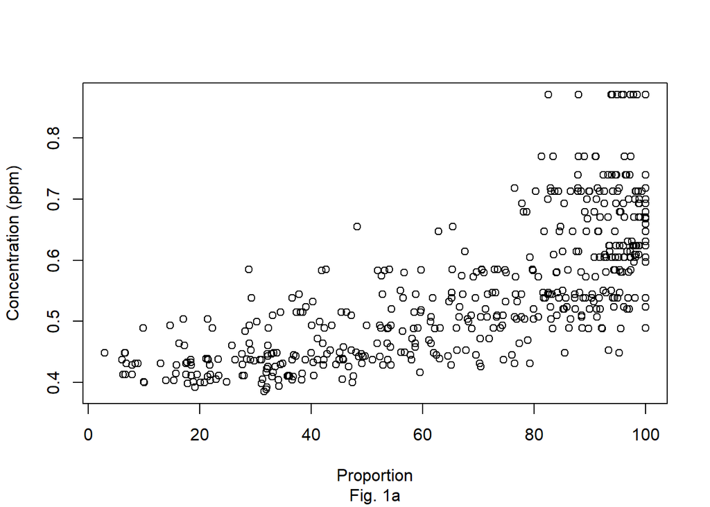

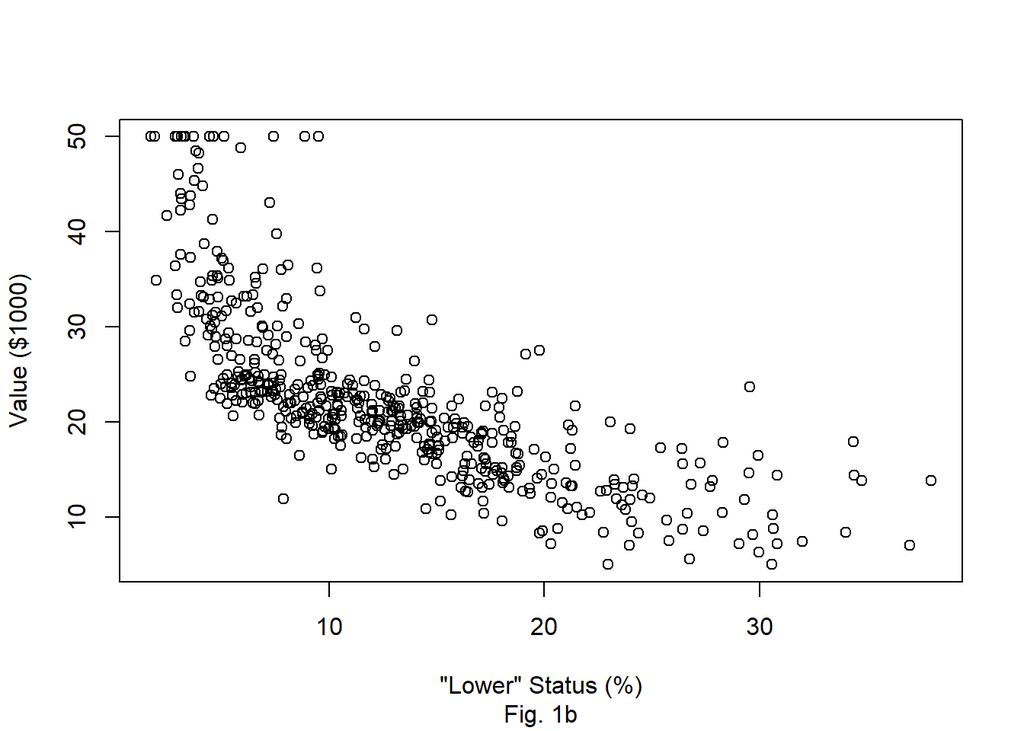

Fig. 1: (a) NO Concentration vs. Proportion of Units Built Before 1940 shows positive correlation. (b) Median Owner-Occupied Household Value vs. Proportion of Lower Status Population shows negative correlation. Examples of typical trends seen between variable pairs in the data set with highest linear correlations; linear correlations likely to improve with variable transformations.

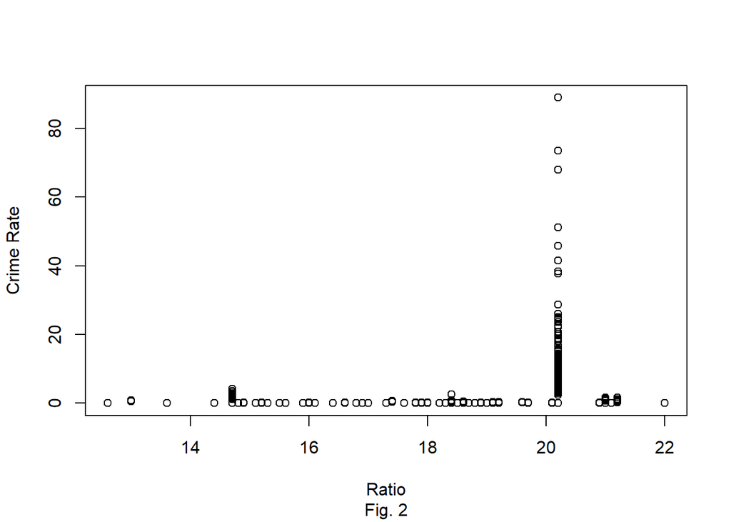

Fig. 2: Per capita crime rate vs. average pupil-teacher ratio. Example of trend seen when per capita crime rate is plotted pairwise against multiple other predictors, where most of the response variation is observed at one specific predictor level. The variation is seen at **ptratio** = 20.2 in this instance.

Table 2: Predictor values and associated percentiles for suburbs with the minimum median household value observed in dataset (**medv** = 5). All predictor levels generally fall in the top or bottom 15% of the range of levels observedin full data set.

```
##                          crim zn indus chas  nox   rm age dis rad tax
## Suburb 399 - Values      38.4  0  18.1    0  0.7  5.5 100 1.5  24 666
## Suburb 399 - Percentiles 98.0 73  88.0   93 85.0  7.0 100 5.0 100  99
## Suburb 406 - Values      67.9  0  18.1    0  0.7  5.7 100 1.4  24 666
## Suburb 406 - Percentiles 99.0 73  88.0   93 85.0 13.0 100 3.0 100  99
##                          ptratio black lstat
## Suburb 399 - Values         20.2 396.9  30.6
## Suburb 399 - Percentiles    88.0 100.0  97.0
## Suburb 406 - Values         20.2 385.0  23.0
## Suburb 406 - Percentiles    88.0  34.0  89.0
```

Table 3: Statistics, p-values, and 95% CIs generated from 2-sample, 2-sided t-tests comparing groups of suburbs with more or less than 8 rooms per dwelling, with null hypothesis of no difference.

```
##               crim      zn  indus    nox     age    dis    rad      tax
## t_statistic  -6.39   0.310 -2.730 -0.610   0.440 -0.710 -1.400   -2.690
## p-value       0.00   0.759  0.017  0.554   0.669  0.493  0.184    0.018
## 95% CI, Low  -3.89 -13.670 -7.460 -0.070 -11.980 -1.520 -5.430 -153.590
## 95% CI, High -2.05  18.300 -0.870  0.040  18.060  0.770  1.150  -17.120
##              ptratio black  lstat  medv
## t_statistic   -3.180  5.76 -17.22  9.77
## p-value        0.008  0.00   0.00  0.00
## 95% CI, Low   -3.610 19.21  -9.57 17.31
## 95% CI, High  -0.680 39.37  -7.55 27.17
```

## Conclusions

Inspection of correlation and scatterplot matrices for the Boston data set revealed multiple linear associations between pairs of variables, as well as other noticeable trends; future analysis should carefully consider these correlations and perhaps eliminate them as to avoid multicollinearity.

Numerical summaries for suburbs having the minimum median household value (**medv** = 5) observed in the data suggested that lower values may be characterized via higher NO concentrations, older homes with relatively few rooms, a higher percentage of lower status population, and close proximities to Boston employment centers. Summaries and t-tests for suburbs found to have a high average number of rooms per dwelling (**rm** > 8) suggested that these suburbs tend to score higher on measures for the predictor **black** and median household value, and lower measures for per capita crime rate, degree of industrialization, property-tax rates, pupil-teacher ratios, and percentage of population regarded as lower status.

## Appendix I: R Code

The following code does not generate any figures and supplements that which is found in the Plots and Tables section.

```r
which(is.na(df) == TRUE) # Locates missing values, if any; returns 0
```

```r
dim(df[df$chas == 1, ]) # [35 14] ==> 35 suburbs bound the Charles River
35/506 # 0.0692 = proportion of suburbs on Charles River
7/127 # 0.0551 = proportion of "high crime" (top 25%) suburbs on Charles River
```

```r
# Conduct 2-sample proportion z-test at 99% confidence
off.river <- c(120, 471)
total <- c(127, 506)
prop.test(off.river, total, conf.level = 0.99)
```

```
##
##  2-sample test for equality of proportions with continuity
##  correction
##
## data:  off.river out of total
## X-squared = 0.13651, df = 1, p-value = 0.7118
## alternative hypothesis: two.sided
## 99 percent confidence interval:
##  -0.05058164  0.07868535
## sample estimates:
##    prop 1    prop 2
## 0.9448819 0.9308300
```

```r
dim(df[df$rm > 7, ]) # [64 14] ==> 64 suburbs average more than 7 rooms/dwelling
dim(df[df$rm > 8, ]) # [13 14] ==> 13 suburbs average more than 8 rooms/dwelling
```